# 10-315 Introduction to Machine Learning (SCS Majors) Lecture 5: Naive Bayes

## Leila Wehbe Carnegie Mellon University Machine Learning Department

Reading: <a href ="http://www.cs.cmu.edu/~tom/mlbook/NBayesLogReg.pdf"> Generative and Disciminative Classifiers </a> by Tom Mitchell.

#### Lecture outcomes:

- Conditional Independence
- Naïve Bayes, Gaussian Naive Bayes
- Practical Examples

## Assume you want to build a classifier for new customers

| $O$ Is older than 35 years | $I$ Has Personal Income | $S$ Is a Student | $J$ Birthday before July 1st | $Y$ Buys computer |
| --- | --- | --- | --- | --- |
| 0 | 1 | 0 | 0 | 0 |
| 0 | 1 | 0 | 1 | 0 |
| 1 | 1 | 0 | 1 | 1 |
| 1 | 1 | 0 | 1 | 1 |
| 1 | 0 | 1 | 0 | 1 |
| 1 | 0 | 1 | 1 | 0 |
| 0 | 0 | 1 | 0 | 1 |
| 0 | 1 | 0 | 0 | 0 |
| 0 | 0 | 1 | 1 | 1 |
| 0 | 1 | 1 | 0 | 1 |
| 0 | 0 | 1 | 1 | 1 |
| 1 | 1 | 0 | 1 | 1 |
| 0 | 1 | 1 | 0 | 1 |
| 1 | 1 | 0 | 0 | 0 |

| $O$ Is older than 35 years | $I$ Has Personal Income | $S$ Is a Student | $J$ Birthday before July 1st | $Y$ Buys computer |
| --- | --- | --- | --- | --- |
| 0 | 1 | 1 | 1 | ? |

## How many parameters must we estimate?

Suppose $X =(X_1,X_2)$ where $X_i$ and $Y$ are boolean random variables

How many parameters do we need to estimate to know $P(Y| X1, X2)$?

## How many parameters must we estimate?

Suppose $X =(X_1,X_2)$ where $X_i$ and $Y$ are boolean random variables

How many parameters do we need to estimate to know $P(Y| X1, X2)$?

| $$X_1$$ | $$X_2$$ | $$P(Y=1\mid X_1,X_2)$$ | $$P(Y=0\mid X_1,X_2)$$ |
| --- | --- | --- | --- |
| 0 | 1 | 0.1 | 0.9 |
| 1 | 0 | 0.24 | 0.76 |
| 0 | 1 | 0.54 | 0.46 |
| 1 | 1 | 0.23 | 0.77 |

## How many parameters must we estimate?

Suppose $X =(X_1,X_2)$ where $X_i$ and $Y$ are boolean random variables

How many parameters do we need to estimate to know $P(Y| X1, X2)$?

| $$X_1$$ | $$X_2$$ | $$P(Y=1\mid X_1,X_2)$$ | $$P(Y=0\mid X_1,X_2)$$ |
| --- | --- | --- | --- |
| 0 | 1 | 0.1 | 0.9 |
| 1 | 0 | 0.24 | 0.76 |
| 0 | 1 | 0.54 | 0.46 |
| 1 | 1 | 0.23 | 0.77 |

4 parameters: $P(Y=0\mid X_1,X_2) = 1-P(Y=1\mid X_1,X_2)$

## How many parameters must we estimate?

Suppose $X =(X_1,X_2, ..., X_d)$ where $X_i$ and $Y$ are boolean random variables

How many parameters do we need to estimate to know $P(Y| X_1, ... X_d)$?

## How many parameters must we estimate?

Suppose $X =(X_1,X_2, ..., X_d)$ where $X_i$ and $Y$ are boolean random variables

How many parameters do we need to estimate to know $P(Y| X_1, ... X_d)$?

| $$X_1$$ | $$X_2$$ | $$X_3$$ | ... | $$X_d$$ | $$P(Y=1\mid X)$$ | $$P(Y=0\mid X)$$ |
| --- | --- | --- | --- | --- | --- | --- |
| 0 | 0 | 0 | ... | 0 | 0.1 | 0.9 |
| 0 | 0 | 0 | ... | 1 | 0.24 | 0.76 |
| ... | ... | ... | ... | ... | ... | ... |
| ... | ... | ... | ... | ... | ... | ... |
| 1 | 1 | 1 | ... | 1 | 0.52 | 0.48 |

## How many parameters must we estimate?

Suppose $X =(X_1,X_2, ..., X_d)$ where $X_i$ and $Y$ are boolean random variables

How many parameters do we need to estimate to know $P(Y| X_1, ... X_d)$?

| $$X_1$$ | $$X_2$$ | $$X_3$$ | ... | $$X_d$$ | $$P(Y=1\mid X)$$ | $$P(Y=0\mid X)$$ |
| --- | --- | --- | --- | --- | --- | --- |
| 0 | 0 | 0 | ... | 0 | 0.1 | 0.9 |
| 0 | 0 | 0 | ... | 1 | 0.24 | 0.76 |
| ... | ... | ... | ... | ... | ... | ... |
| ... | ... | ... | ... | ... | ... | ... |
| 1 | 1 | 1 | ... | 1 | 0.52 | 0.48 |

$2^d$ rows! ($2^d$ parameters!).

If we have 30 boolean $X_i$'s: ~ 1 billion rows!

## Last Lecture we asked:

### Can we just estimate P(Y|X) in this fashion and be done?

We might not have enough data. For example consider having 100 attributes of people:

- how many rows will we have? $2^{100}> 10^{30}$
- how many people on earth? $10^{10}$
- 99.99\% of rows will not have training examples!

## Can we use Bayes Rule to reduce the number of parameters?

We used bayes rule last lecture to express marginal and conditional probabilities of the data and parameter $\theta$:

$$ P(\theta|D) = \frac{P(D|\theta)P(\theta)}{P(D)} $$

We can also express the conditional distribution of $Y$ given $X$:

$$ P(Y|X) = \frac{P(X|Y)P(Y)}{P(X)} $$

BTW, this notation is a shorthand for:

$$ (\forall i, j) ~ P(Y=y_i|X=x_j) = \frac{P(X=x_j|Y=y_i)P(Y=y_i)}{P(X=x_j)} $$

## Can we use Bayes Rule to reduce the number of parameters?

We used bayes rule last lecture to express marginal and conditional probabilities of the data and parameter $\theta$:

$$ P(\theta|D) = \frac{P(D|\theta)P(\theta)}{P(D)} $$

We can also express the conditional distribution of $Y$ given $X$:

$$ P(Y|X) = \frac{P(X|Y)P(Y)}{P(X)} $$

BTW, this notation is a shorthand for:

$$ (\forall i, j) ~ P(Y=y_i|X=x_j) = \frac{P(X=x_j|Y=y_i)P(Y=y_i)}{P(X=x_j)} $$

Equivalently:

$$ (\forall i, j) ~ P(Y=y_i|X=x_j) = \frac{P(X=x_j|Y=y_i)P(Y=y_i)}{{\sum_k P(X=x_i|Y=y_k)P(Y=y_k)}} $$

## Does Bayes Rule help reduce the number of parameters?

$$ P(Y|X) = \frac{P(X|Y)P(Y)}{P(X)} $$

- $P(X)$ is the same for both classes, so we might be able to avoid computing it (also, I can get it for free if I already know $P(X|Y)$ and $P(Y)$).
- $P(Y)$ is only 1 parameter.
- What about $P(X|Y)$? i.e. $P(X_1,X_2,...X_d|Y)$. How many parameters do we need?

## How many parameters do we need for $P(X_1,X_2,...X_d|Y)$?

| $$Y$$ | $$X_1$$ | $$X_2$$ | $$X_3$$ | ... | $$X_d$$ | $$P(X\mid Y)$$ |
| --- | --- | --- | --- | --- | --- | --- |
| 0 | 0 | 0 | 0 | ... | 0 | 0.1 |
| 0 | 0 | 0 | 0 | ... | 1 | 0.02 |
| 0 | ... | ... | ... | ... | ... | ... |
| 0 | 1 | 1 | 1 | ... | 1 | 0.16 |
| 1 | 0 | 0 | 0 | ... | 0 | ? |
| 1 | 0 | 0 | 0 | ... | 1 | ? |
| 1 | ... | ... | ... | ... | ... | ? |
| 1 | 1 | 1 | 1 | ... | 1 | ? |

- How many parameters for the red cells?
- Should I compute parameters for the blue cells as well?

## How many parameters do we need for $P(X_1,X_2,...X_d|Y)$?

| $$Y$$ | $$X_1$$ | $$X_2$$ | $$X_3$$ | ... | $$X_d$$ | $$P(X\mid Y)$$ |
| --- | --- | --- | --- | --- | --- | --- |
| 0 | 0 | 0 | 0 | ... | 0 | 0.1 |
| 0 | 0 | 0 | 0 | ... | 1 | 0.02 |
| 0 | ... | ... | ... | ... | ... | ... |
| 0 | 1 | 1 | 1 | ... | 1 | 0.16 |
| 1 | 0 | 0 | 0 | ... | 0 | 0.03 |
| 1 | 0 | 0 | 0 | ... | 1 | 0.2 |
| 1 | ... | ... | ... | ... | ... | ... |
| 1 | 1 | 1 | 1 | ... | 1 | 0.01 |

- How many parameters for the red cells? $2^d-1$
- Should I compute parameters for the blue cells as well? yes, $2^d-1$

## Does Bayes Rule help reduce the number of parameters?

$$ P(Y|X) = \frac{P(X|Y)P(Y)}{P(X)} $$

- $P(X)$ is the same for both classes, so we might be able to avoid computing it (also, I can get it for free if I already know $P(X|Y)$ and $P(Y)$).
- $P(Y)$ is only 1 parameter.
- $P(X_1,X_2,...X_d|Y)$: $2(2^d-1)$ parameters

**Still too many parameters!**

If we have 30 boolean $X_i$'s: ~ 2 billion!

## Solution:

1- Be smart about how to estimate probabilities from sparse data

- maximum likelihood estimates
- maximum a posteriori estimates
- Be smart about how to represent joint distributions
- Bayes networks, graphical models, conditional independence

## Be smart about how to represent joint distributions

#### Conditional Independence:

**Definition:** $X$ is conditionally independent of $Y$ given $Z$, if the probability distribution governing $X$ is independent of the value of $Y$, given the value of $Z$.

$$ (\forall i, j, k) ~ P(X=x_i|Y=y_j, Z = z_k) = P(X=x_i|Z=z_j) $$

Which we often write:

$$P(X|Y,Z) = P(X|Z)$$

For example: $P(\text{thunder}|\text{rain}, \text{lightning}) = P(\text{thunder}| \text{lightning}) $

- Thunder is independent of rain **given lightning**.
  - Once we know there if there is or there is lightning, no more information is provided by the value of rain.
- **This does not mean that thunder is independent of rain**.

### The Naïve Bayes Algorithm

Naïve Bayes is a classifier that assumes conditional independence of the variables $X_i$ given the label $Y$. For example: $P(X_1|X_2,Y) = P(X_1|Y)$

How does this assumption simplify $P(X_1,X_2|Y)$?

### The Naïve Bayes Algorithm

Naïve Bayes is a classifier that assumes conditional independence of the variables $X_i$ given the label $Y$. For example: $P(X_1|X_2,Y) = P(X_1|Y)$

How does this assumption simplify $P(X_1,X_2|Y)$?

\begin{eqnarray} P(X_1,X_2|Y) &=& P(X_1|X_2,Y)P(X_2|Y) ~~~~~~~~~~~~~~~~~~~~~~~ \text{(chain rule)} \\ \end{eqnarray}

### The Naïve Bayes Algorithm

Naïve Bayes is a classifier that assumes conditional independence of the variables $X_i$ given the label $Y$. For example: $P(X_1|X_2,Y) = P(X_1|Y)$

How does this assumption simplify $P(X_1,X_2|Y)$?

\begin{eqnarray} P(X_1,X_2|Y) &=& P(X_1|X_2,Y)P(X_2|Y) ~~~~~~~~~~~~~~~~~~~~~~~ \text{(chain rule)} \\ &=& P(X_1|Y)P(X_2|Y) ~ ~ ~ \text{(conditional independence)} \end{eqnarray}

### The Naïve Bayes Algorithm

Naïve Bayes is a classifier that assumes conditional independence of the variables $X_i$ given the label $Y$. For example: $P(X_1|X_2,Y) = P(X_1|Y)$

How does this assumption simplify $P(X_1,X_2|Y)$?

\begin{eqnarray} P(X_1,X_2|Y) &=& P(X_1|X_2,Y)P(X_2|Y) ~~~~~~~~~~~~~~~~~~~~~~~ \text{(chain rule)} \\ &=& P(X_1|Y)P(X_2|Y) ~ ~ ~ \text{(conditional independence)} \end{eqnarray}

In general:

\begin{eqnarray} P(X_1,...,X_d|Y) &=&\prod_i P(X_i|,Y) \end{eqnarray}

### The Naïve Bayes Algorithm

Naïve Bayes is a classifier that assumes conditional independence of the variables $X_i$ given the label $Y$. For example: $P(X_1|X_2,Y) = P(X_1|Y)$

How does this assumption simplify $P(X_1,X_2|Y)$?

\begin{eqnarray} P(X_1,X_2|Y) &=& P(X_1|X_2,Y)P(X_2|Y) ~~~~~~~~~~~~~~~~~~~~~~~ \text{(chain rule)} \\ &=& P(X_1|Y)P(X_2|Y) ~ ~ ~ \text{(conditional independence)} \end{eqnarray}

In general:

\begin{eqnarray} P(X_1,...,X_d|Y) &=&\prod_i P(X_i|,Y) \end{eqnarray}

How many parameters do we need to describe $P(X_1...X_n|Y)$?

- Without the conditional independence assumption: $2(2^d-1)$
- With the conditional independence assumption:

### The Naïve Bayes Algorithm

Naïve Bayes is a classifier that assumes conditional independence of the variables $X_i$ given the label $Y$. For example: $P(X_1|X_2,Y) = P(X_1|Y)$

How does this assumption simplify $P(X_1,X_2|Y)$?

\begin{eqnarray} P(X_1,X_2|Y) &=& P(X_1|X_2,Y)P(X_2|Y) ~~~~~~~~~~~~~~~~~~~~~~~ \text{(chain rule)} \\ &=& P(X_1|Y)P(X_2|Y) ~ ~ ~ \text{(conditional independence)} \end{eqnarray}

In general:

\begin{eqnarray} P(X_1,...,X_d|Y) &=&\prod_i P(X_i|,Y) \end{eqnarray}

How many parameters do we need to describe $P(X_1...X_n|Y)$?

- Without the conditional independence assumption: $2(2^d-1)$
- With the conditional independence assumption: $2d$

### The Naïve Bayes Algorithm

Naïve Bayes assumes conditional independence of the $X_i$'s: $P(X_1,...,X_d|Y) =\prod_i P(X_i|,Y)$

(more on this assumption soon!)

Using Bayes rule with that assumption:

$$ P(Y=y_k|X_1,...,X_d) = \frac{P(Y=y_k) \prod_i P(X_i|Y=y_k) }{P(X)} $$

### The Naïve Bayes Algorithm

Naïve Bayes assumes conditional independence of the $X_i$'s: $P(X_1,...,X_d|Y) =\prod_i P(X_i|,Y)$

(more on this assumption soon!)

Using Bayes rule with that assumption:

$$ P(Y=y_k|X_1,...,X_d) = \frac{P(Y=y_k) \prod_i P(X_i|Y=y_k) }{P(X)} $$

- Train the algorithm (estimate $P(X_i|Y=y_k)$ and $P(Y=y_k)$)
- To classify, pick the most probable $Y^{\text{new}}$ for a new sample $X^{\text{new}} = (X_1^{\text{new}},X_2^{\text{new}},...,X_d^{\text{new}})$ as:

$$ Y^{\text{new}} \leftarrow \underset{y_k}{\operatorname{argmax}} P(Y=y_k) \prod_i P(X_i^{\text{new}}|Y=y_k) $$

### Naïve Bayes - Training and Prediction Phase - Discrete $X_i$

Training:

- Estimate $\pi_k \equiv P(Y=y_k)$
- Estimate $\theta_{ijk} \equiv P(X_i=x_{ij}|Y=y_k) $
  - $\theta_{ijk}$ is computed for each label $y_k$:
    - For each variable $X_i$:
      - For each value $x_{ij}$ that $X_i$ can take.
  - Example: if $X_1$ is binary, $P(X_1|Y=0)$ is a bernouilli distribution, where:
    - the probability of $X_1 = 0$ given $Y=0$ is $\theta_{100}$
    - the probability of $X_1 = 1$ given $Y=0$ is $\theta_{110}$
    - $\theta_{100} = 1- \theta_{110}$.

### Naïve Bayes - Training and Prediction Phase - Discrete $X_i$

Training:

- Estimate $\pi_k \equiv P(Y=y_k)$, get $\hat\pi_k$
- Estimate $\theta_{ijk} \equiv P(X_i=x_{ij}|Y=y_k) $, get $\hat\theta_{ijk}$
  - $\theta_{ijk}$ is estimate for each label $y_k$:
    - For each variable $X_i$:
      - For each value $x_{ij}$ that $X_i$ can take.
- Prediction: Classify $Y^{\text{new}}$ \begin{eqnarray}Y^{\text{new}} &=& \underset{y_k}{\operatorname{argmax}} P(Y=y_k) \prod_i P(X^{\text{new}}_i=x^{\text{new}}_j|Y=y_k) \\ &=& \underset{y_k}{\operatorname{argmax}} \pi_k\prod_i \theta_{i,X^\text{new}_i,k} \end{eqnarray}

But... how do we estimate these parameters?

### Naïve Bayes - Training Phase - Discrete $X_i$ - Maximum (Conditional) Likelihood Estimation

$P(X|Y=y_k)$ has parameters $\theta_{ijk}$, one for each value $x_{ij}$ of each $X_i$. $P(Y)$ has parameters $\pi$.

To follow the MLE principle, we pick the parameters $\pi$ and $\theta$ that maximizes the (**conditional**) likelihood of the data given the parameters.

To estimate:

- Compute $$\hat\pi_k = \hat P(Y=y_k) = \frac{\# D(Y=y_k)}{|D|}$$
- For each label $y_k$:
  - For each variable $X_i$:
    - For each value $x_{ij}$ that $X_i$ can take, compute: $$\hat\theta_{ijk}= \hat P(X_i=x_{ij}|Y=y_k) = \frac{\# D(X_i=x_{ij} \wedge Y=y_k)}{\# D(Y=y_k)}$$ .

## Let's train!

| $O$ Is older than 35 years | $I$ Has Personal Income | $S$ Is a Student | $J$ Birthday before July 1st | $Y$ Buys computer |
| --- | --- | --- | --- | --- |
| 0 | 1 | 0 | 0 | 0 |
| 0 | 1 | 0 | 1 | 0 |
| 1 | 1 | 0 | 1 | 1 |
| 1 | 1 | 0 | 1 | 1 |
| 1 | 0 | 1 | 0 | 1 |
| 1 | 0 | 1 | 1 | 0 |
| 0 | 0 | 1 | 0 | 1 |
| 0 | 1 | 0 | 0 | 0 |
| 0 | 0 | 1 | 1 | 1 |
| 0 | 1 | 1 | 0 | 1 |
| 0 | 0 | 1 | 1 | 1 |
| 1 | 1 | 0 | 1 | 1 |
| 0 | 1 | 1 | 0 | 1 |
| 1 | 1 | 0 | 0 | 0 |

## Let's train!

Removed one variable to simplify the problem + changed order of samples.

O= Is older than 35, S= Is a student, J = Birthday before July 1, Y= buys computer

| $$O$$ | $$S$$ | $$J$$ | $$Y$$ |
| --- | --- | --- | --- |
| 0 | 0 | 0 | **0** |
| 0 | 0 | 1 | **0** |
| 0 | 0 | 0 | **0** |
| 1 | 1 | 1 | **0** |
| 1 | 0 | 0 | **0** |
| 0 | 1 | 0 | **1** |
| 1 | 0 | 1 | **1** |
| 1 | 0 | 1 | **1** |
| 1 | 1 | 0 | **1** |
| 0 | 1 | 1 | **1** |
| 0 | 1 | 0 | **1** |
| 0 | 1 | 1 | **1** |
| 1 | 0 | 1 | **1** |
| 0 | 1 | 0 | **1** |

## Let's train!

O= Is older than 35, S= Is a student, J = Birthday before July 1, Y= buys computer

| $Y = 1$ | $~$ | $Y = 0$ |  |  |
| --- | --- | --- | --- | --- |
| P(Y=1) = |  | P(Y=0) = |  |  |
| P(O=1\ | Y=1) = |  | P(O=1\ | Y=0) = |
| P(O=0\ | Y=1) = |  | P(O=0\ | Y=0) = |
| P(S=1\ | Y=1) = |  | P(S=1\ | Y=0) = |
| P(S=0\ | Y=1) = |  | P(S=0\ | Y=0) = |
| P(J=1\ | Y=1) = |  | P(J=1\ | Y=0) = |
| P(J=0\ | Y=1) = |  | P(J=0\ | Y=0) = |

## Let's train!

O= Is older than 35, S= Is a student, J = Birthday before July 1, Y= buys computer

| $Y = 1$ | $~$ | $Y = 0$ |  |  |
| --- | --- | --- | --- | --- |
| P(Y=1) = 9/14 |  | P(Y=0) = 5/14 |  |  |
| P(O=1\ | Y=1) = |  | P(O=1\ | Y=0) = |
| P(O=0\ | Y=1) = |  | P(O=0\ | Y=0) = |
| P(S=1\ | Y=1) = |  | P(S=1\ | Y=0) = |
| P(S=0\ | Y=1) = |  | P(S=0\ | Y=0) = |
| P(J=1\ | Y=1) = |  | P(J=1\ | Y=0) = |
| P(J=0\ | Y=1) = |  | P(J=0\ | Y=0) = |

## Let's train!

O= Is older than 35, S= Is a student, J = Birthday before July 1, Y= buys computer

| $Y = 1$ | $~$ | $Y = 0$ |  |  |
| --- | --- | --- | --- | --- |
| P(Y=1) = 9/14 |  | P(Y=0) = 5/14 |  |  |
| P(O=1\ | Y=1) = 4/9</font> |  | P(O=1\ | Y=0) = |
| P(O=0\ | Y=1) = |  | P(O=0\ | Y=0) = |
| P(S=1\ | Y=1) = |  | P(S=1\ | Y=0) = |
| P(S=0\ | Y=1) = |  | P(S=0\ | Y=0) = |
| P(J=1\ | Y=1) = |  | P(J=1\ | Y=0) = |
| P(J=0\ | Y=1) = |  | P(J=0\ | Y=0) = |

## Let's train!

O= Is older than 35, S= Is a student, J = Birthday before July 1, Y= buys computer

| $Y = 1$ | $~$ | $Y = 0$ |  |  |
| --- | --- | --- | --- | --- |
| P(Y=1) = 9/14 |  | P(Y=0) = 5/14 |  |  |
| P(O=1\ | Y=1) = 4/9</font> |  | P(O=1\ | Y=0) = 2/5 </font> |
| P(O=0\ | Y=1) = 5/9 </font> |  | P(O=0\ | Y=0) = |
| P(S=1\ | Y=1) = |  | P(S=1\ | Y=0) = |
| P(S=0\ | Y=1) = |  | P(S=0\ | Y=0) = |
| P(J=1\ | Y=1) = |  | P(J=1\ | Y=0) = |
| P(J=0\ | Y=1) = |  | P(J=0\ | Y=0) = |

## Let's train!

O= Is older than 35, S= Is a student, J = Birthday before July 1, Y= buys computer

| $Y = 1$ | $~$ | $Y = 0$ |  |  |
| --- | --- | --- | --- | --- |
| P(Y=1) = 9/14 |  | P(Y=0) = 5/14 |  |  |
| P(O=1\ | Y=1) = 4/9</font> |  | P(O=1\ | Y=0) = 2/5 </font> |
| P(O=0\ | Y=1) = 5/9 </font> |  | P(O=0\ | Y=0) = 3/5 |
| P(S=1\ | Y=1) = 6/9 |  | P(S=1\ | Y=0) = 1/5 |
| P(S=0\ | Y=1) = 3/9 |  | P(S=0\ | Y=0) = 4/5 |
| P(J=1\ | Y=1) = 5/9 |  | P(J=1\ | Y=0) = 2/5 |
| P(J=0\ | Y=1) = 4/9 |  | P(J=0\ | Y=0) = 3/5 |

## Let's predict!

O= Is older than 35, S= Is a student, J = Birthday before July 1, Y= buys computer

| $Y = 1$ | $~$ | $Y = 0$ |  |  |
| --- | --- | --- | --- | --- |
| P(Y=1) = 9/14 |  | P(Y=0) = 5/14 |  |  |
| P(O=1\ | Y=1) = 4/9</font> |  | P(O=1\ | Y=0) = 2/5 </font> |
| P(O=0\ | Y=1) = 5/9 </font> |  | P(O=0\ | Y=0) = 3/5 |
| P(S=1\ | Y=1) = 6/9 |  | P(S=1\ | Y=0) = 1/5 |
| P(S=0\ | Y=1) = 3/9 |  | P(S=0\ | Y=0) = 4/5 |
| P(J=1\ | Y=1) = 5/9 |  | P(J=1\ | Y=0) = 2/5 |
| P(J=0\ | Y=1) = 4/9 |  | P(J=0\ | Y=0) = 3/5 |

| $$O$$ | $$S$$ | $$J$$ | $$Y$$ |
| --- | --- | --- | --- |
| 0 | 1 | 1 | ? |

## Let's predict!

O= Is older than 35, S= Is a student, J = Birthday before July 1, Y= buys computer

| $Y = 1$ | $~$ | $Y = 0$ |  |  |
| --- | --- | --- | --- | --- |
| P(Y=1) = 9/14 |  | P(Y=0) = 5/14 |  |  |
| P(O=1\ | Y=1) = 4/9</font> |  | P(O=1\ | Y=0) = 2/5 </font> |
| P(O=0\ | Y=1) = 5/9 </font> |  | P(O=0\ | Y=0) = 3/5 |
| P(S=1\ | Y=1) = 6/9 |  | P(S=1\ | Y=0) = 1/5 |
| P(S=0\ | Y=1) = 3/9 |  | P(S=0\ | Y=0) = 4/5 |
| P(J=1\ | Y=1) = 5/9 |  | P(J=1\ | Y=0) = 2/5 |
| P(J=0\ | Y=1) = 4/9 |  | P(J=0\ | Y=0) = 3/5 |

| $$O$$ | $$S$$ | $$J$$ | $$Y$$ |
| --- | --- | --- | --- |
| 0 | 1 | 1 | ? |

\begin{eqnarray}Y^{\text{new}} &=& \underset{y_k}{\operatorname{argmax}} P(Y=y_k) P(O=0, S = 1, J = 1 | Y=y_k) \\ &=&\underset{y_k}{\operatorname{argmax}} P(Y=y_k) P(O=0| Y=y_k)P(S = 1 | Y=y_k) P( J = 1 | Y=y_k) \end{eqnarray}

P(Y=1) P(O=0| Y=1)P(S = 1 | Y=1) P( J = 1 | Y=1) = 9/14 * 5/9 * 6/9 * 5/9 =0.13

## Let's predict!

O= Is older than 35, S= Is a student, J = Birthday before July 1, Y= buys computer

| $Y = 1$ | $~$ | $Y = 0$ |  |  |
| --- | --- | --- | --- | --- |
| P(Y=1) = 9/14 |  | P(Y=0) = 5/14 |  |  |
| P(O=1\ | Y=1) = 4/9</font> |  | P(O=1\ | Y=0) = 2/5 </font> |
| P(O=0\ | Y=1) = 5/9 </font> |  | P(O=0\ | Y=0) = 3/5 |
| P(S=1\ | Y=1) = 6/9 |  | P(S=1\ | Y=0) = 1/5 |
| P(S=0\ | Y=1) = 3/9 |  | P(S=0\ | Y=0) = 4/5 |
| P(J=1\ | Y=1) = 5/9 |  | P(J=1\ | Y=0) = 2/5 |
| P(J=0\ | Y=1) = 4/9 |  | P(J=0\ | Y=0) = 3/5 |

| $$O$$ | $$S$$ | $$J$$ | $$Y$$ |
| --- | --- | --- | --- |
| 0 | 1 | 1 | ? |

\begin{eqnarray}Y^{\text{new}} &=& \underset{y_k}{\operatorname{argmax}} P(Y=y_k) P(O=0, S = 1, J = 1 | Y=y_k) \\ &=&\underset{y_k}{\operatorname{argmax}} P(Y=y_k) P(O=0| Y=y_k)P(S = 1 | Y=y_k) P( J = 1 | Y=y_k) \end{eqnarray}

P(Y=1) P(O=0| Y=1)P(S = 1 | Y=1) P( J = 1 | Y=1) = 9/14 * 5/9 * 6/9 * 5/9 =0.132

P(Y=0) P(O=0| Y=0)P(S = 1 | Y=0) P( J = 1 | Y=0) = 5/14 * 3/5 * 1/5 * 2/5 = 0.017

Pick label 1!

## Can also compute P(Y|X):

Not required to make predictions, but we have everything we need:

$$ P(Y|X) = \frac{P(X|Y)P(Y)}{P(X)} $$$$P(X) = \sum_k P(X|Y=y_k)P(Y=y_k)$$

P(Y=1) P(O=0| Y=1)P(S = 1 | Y=1) P( J = 1 | Y=1) = 0.132

P(Y=0) P(O=0| Y=0)P(S = 1 | Y=0) P( J = 1 | Y=0) = 0.017

P(Y=1 \| O=0, S = 1, J = 1 ) = 0.886

P(Y=0 \| O=0, S = 1, J = 1 ) = 0.114

## Classification Accuracy

- To get an estimate of generalization performance, compute accuracy on held-out set (more about this soon).
  - Never train on your test data!
- Assume you train and use this algorithm to predict "Buy Computer?" with a large dataset, and obtain binary classification accuracy of 75%.
  - What does this mean? Is it good or bad?

## Classification Accuracy

- What if 70% is the probability of $Y=1$. Is 75% impressive?
  - What is an easy way to obtain 70\% classification accuracy?

## Classification Accuracy

- What if 70% is the probability of $Y=1$. Is 75% impressive?
  - What is an easy way to obtain 70\% classification accuracy?
- What is chance performance?

## Classification Accuracy

- What if 70% is the probability of $Y=1$. Is 75% impressive?
  - What is an easy way to obtain 70\% classification accuracy?
- What is chance performance?
- What is the accuracy if I flip an unbiased coin?

## Classification Accuracy

- What if 70% is the probability of $Y=1$. Is 75% impressive?
  - What is an easy way to obtain 70\% classification accuracy?
- What is chance performance?
- What is the accuracy if I flip an unbiased coin?
- If P(Y=1)>0.5, then we can just predict 1 all the time!
  - What will be the accuracy?

## Classification Accuracy

- What if 70% is the probability of $Y=1$. Is 75% impressive?
  - What is an easy way to obtain 70\% classification accuracy?
- What is chance performance?
- What is the accuracy if I flip an unbiased coin?
- If P(Y=1)>0.5, then we can just predict 1 all the time!
  - What will be the accuracy?
- What happens if you predict Y=1 with probability 0.7 ==> this is called probability matching in cognitive science

## Naïve Bayes observation 1

Usually the $X_i$ are not conditionally independent: $$P(X_1,...,X_d|Y) \ne\prod_i P(X_i|,Y)$$

- Even if the "naïve" conditional independence assumption is not true in the data, Naïve Bayes might still perform well and is used anyways
  - often the right classification, even when not the right probability (see [Domingos&Pazzani, 1996])

## Naïve Bayes observation 1

Usually the $X_i$ are not conditionally independent: $$P(X_1,...,X_d|Y) \ne\prod_i P(X_i|,Y)$$

- Even if the "naïve" conditional independence assumption is not true in the data, Naïve Bayes might still perform well and is used anyways
  - often the right classification, even when not the right probability (see [Domingos&Pazzani, 1996])
- To see the effect of the violation of this assumption, consider the extreme case in which $X_i$ is a copy of $X_k$. What is the effect on $P(Y|X)$?
- To see the effect of the violation of the conditional independence assumption, consider the extreme case in which $X_i$ is a copy of $X_k$. What is the effect on $P(Y|X)$?

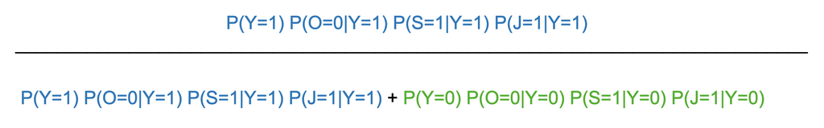

- To see the effect of the violation of the conditional independence assumption, consider the extreme case in which $X_i$ is a copy of $X_k$. What is the effect on $P(Y|X)$?

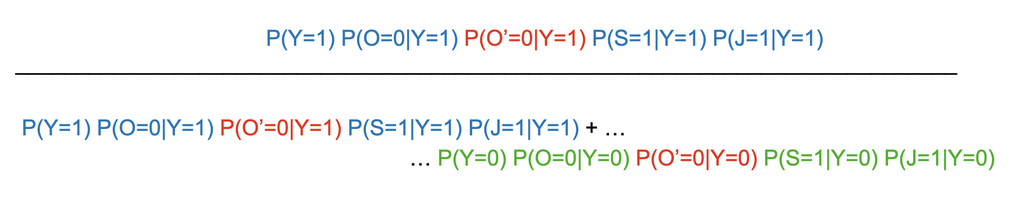

Consider for example that $P(O=1|Y=1)> P(O=1|Y=0)$, how does $P(Y=1|O=1,O^\prime=1,S=1,J=1)$ with the duplicated variable compare to respect $P(Y=1|O=1,S=1,J=1)$?

## Naïve Bayes observation 2

What if we have an irrelevant variable?

## Naïve Bayes observation 2

What if we have an irrelevant variable?

Assume J is independent of $Y$: $P(J|Y=0) = P(J|Y=1)= P(J)$

Does it hurt classification?

## Naïve Bayes observation 2

What if we have an irrelevant variable?

Assume J is independent of $Y$: $P(J|Y=0) = P(J|Y=1)= P(J)$

Does it hurt classification?

- If we have the correct estimates, then performance is not affected.
- If we have noisy estimates, performance is affected.</font>

## Naïve Bayes observation 3

Another way to view Naïve Bayes with Boolean $Y$ and $X_i$s is:

Decision rule: is this quantity greater or less than 1?

\begin{eqnarray} \frac{P(Y=1|X_1...X_d)}{P(Y=0|X_1...X_d)} = \frac{P(Y=1)P(X_1...X_d|Y=1)}{P(Y=0)P(X_1...X_d|Y=0)} ~ ~ ~ ~ ~ > \text{ or } <1? \end{eqnarray}

Practical concern: What happens when d is large?

## Naïve Bayes observation 3

Another way to view Naïve Bayes with Boolean $Y$ and $X_i$s is:

Decision rule: is this quantity greater or less than 1?

\begin{eqnarray} \frac{P(Y=1|X_1...X_d)}{P(Y=0|X_1...X_d)} = \frac{P(Y=1)P(X_1...X_d|Y=1)}{P(Y=0)P(X_1...X_d|Y=0)} ~ ~ ~ ~ ~ > \text{ or } <1? \end{eqnarray}

Taking the log of this ratio prevents **underflow** and expresses the decision rule in a useful way

(we will see later more reasons why it's useful).

\begin{eqnarray} \ln \frac{P(Y=1|X_1...X_d)}{P(Y=0|X_1...X_d)} = \ln \frac{P(Y=1)}{P(Y=0)} + \sum_i\ln \frac{P(X_i|Y=1)}{P(X_i|Y=0)} ~ ~ ~ ~ ~ > \text{ or } <0? \end{eqnarray}

Since $X_i$s are boolean, we can simplify the notation:

- $\theta_{ik} = \hat P(X_i=1|Y=k)$
- $1- \theta_{ik} = \hat P(X_i=0|Y=k)$

\begin{eqnarray} \ln \frac{P(Y=1|X_1...X_d)}{P(Y=0|X_1...X_d)} &=& \ln \frac{P(Y=1)}{P(Y=0)} + \sum_i\ln \frac{P(X_i|Y=1)}{P(X_i|Y=0)} \\ &=& \ln \frac{P(Y=1)}{P(Y=0)} + \sum_i X_i \ln \frac{\theta_{i1} }{\theta_{i0} } + \sum_i (1-X_i) \ln \frac{1-\theta_{i1} }{1-\theta_{i0} } \end{eqnarray}

## Naïve Bayes observation 4

If unlucky, our MLE estimate for $P(X_i | Y)$ might be zero.

- for example, $X_i$ = birthdate. $xi$ = Jan_25_1992.

• Why worry about just one parameter out of many?

## Naïve Bayes observation 4

If unlucky, our MLE estimate for $P(X_i | Y=y_k)$ might be zero.

- for example, $X_i$ = birthdate. $xi$ = Jan_25_1992.
- Why worry about just one parameter out of many?

$$ P(Y=y_k)P(X_1|Y=y_k) P(X_2|Y=y_k) ... P(X_d|Y=y_k) $$

What happens if one of the $P(X_i|Y=y_k)$ is zero?

- What can be done to address this?

## Naïve Bayes - Training Phase - Discrete $X_i$

#### Method 1: Maximum (Conditional) Likelihood Estimation

$P(X|Y=y_k)$ has parameters $\theta_{ijk}$, one for each value $x_{ij}$ of each $X_i$.

To follow the MLE principle, we pick the parameters $\theta$ that maximizes the **conditional** likelihood of the data given the parameters.

#### Method 2: Maximum A Posteriori Probability Estimation

To follow the MAP principle, pick the parameters $\theta$ with maximum posterior probability given the conditional likelihood of the data and the prior on $\theta$.

## Naïve Bayes - Training Phase - Discrete $X_i$

#### Method 1: Maximum (Conditional) Likelihood Estimation

To estimate:

- Compute $$\hat\pi_k = \hat P(Y=y_k) = \frac{\# D(Y=y_k)}{|D|}$$
- For each label $y_k$:
  - For each variable $X_i$:
    - For each value $x_{ij}$ that $X_i$ can take, compute: $$\hat\theta_{ijk}= \hat P(X_i=x_{ij}|Y=y_k) = \frac{\# D(X_i=x_{ij} \wedge Y=y_k)}{\# D(Y=y_k)}.$$

#### Method 2: Maximum A Posteriori Probability Estimation (Beta or Dirichlet priors)

- $K$: the number of values $Y$ can take
- $J$: the number of values $X$ can take (we assume here that all $X_j$ have the same number of possible values, but this can be changed)
- Example prior for $\pi_k$ where $K$ > 2:
  - $\text{Dirichlet}(\beta_\pi,\beta_\pi,..,\beta_\pi)$ prior. (optionally, you can choose different values for each parameter to encode a different weighting).
  - if $K=2$ this becomes a Beta prior.
- Example prior for $\theta_{ijk}$ where J>2 :
  - $\text{Dirichlet}(\beta_\theta,\beta_\theta,..,\beta_\theta)$ prior. (optionally, you can choose different values for each parameter to encode a different weighting, you can choose a different prior per $X_i$ or even per label $y_k$).
  - if $J=2$ this becomes a Beta prior.

#### Method 2: Maximum A Posteriori Probability Estimation (Beta or Dirichlet priors)

- $K$: the number of values $Y$ can take
- $J$: the number of values $X$ can take

These priors will act as imaginary examples that smooth the estimated distributions and prevent zero values.

To estimate:

- Compute $$\hat\pi_k = \hat P(Y=y_k) = \frac{\# D(Y=y_k) +(\beta_\pi -1)}{|D| + K(\beta_\pi -1)}$$
- For each label $y_k$:
  - For each variable $X_i$:
    - For each value $x_{ij}$ that $X_i$ can take, compute: $$\hat\theta_{ijk}= \hat P(X_i=x_{ij}|Y=y_k) = \frac{\# D(X_i=x_{ij} \wedge Y=y_k) + (\beta_\theta -1)}{\# D(Y=y_k) + J(\beta_\theta -1)}$$ .

## What you should know

Naïve Bayes classifier

- What’s the assumption
- Why we use it
- How do we learn it
- The different observations we made about it
- Why is Bayesian estimation important